# Exercise 1

# Exercise 6

If we remember what I did in Lab 2 back in october. I talked about the different properties of Fourier trnasform in Exercise 5. This exercise is a continuation and talks about another property. But in this case this we have to discard an hypothecial property. This property does not hold... But if you look closely it looks a lot like the convolutional theorem, because it indeed is another form of the convolutional theorem. It seems. That the convolutional theorem has two diffrent forms. The one we have already seen and $I\times M = FT^{-1}((FT(I)*FT(M))$: the elemnt-wise product of the images is equal to the convolution of their fourier transforms. The only problem is that I could not get it work that way. Maybe there is something I did not completely understand?

```
2 None None
```

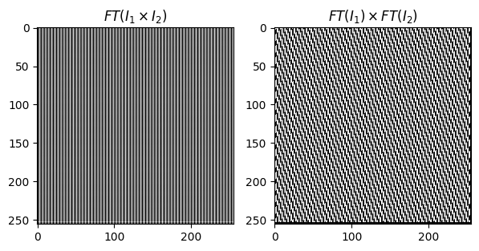

```python
stp1 = np.array(Image.open('./imgs-P3/stp1.gif').convert('L'))
stp2 = np.array(Image.open('./imgs-P3/stp2.gif').convert('L'))
F1 = FT(stp1)
F2 = FT(stp2)
res1 = F1 * F2
res2 = FT(stp1 * stp2)
inv_comb1 = np.absolute(IFT(res1))
inv_comb2 = np.absolute(IFT(res2))
vpu.showInGrid([inv_comb1, inv_comb2], figure_size, subtitles=["$FT(I_1\\times I_2)$","$FT(I_1)\\times FT(I_2)$"])
```

# Exercise 7

It is the same code of the band pass filter but adding some smothing to the mask. If the filter elements are far away from the ones that are going to be set to 1, we set them to 0. And as they move closer to the elements set to 1 their values becomes closer to 1. The level of smoothenes could even be controled by modifying the exponent of the equation.

```python
def bandPassFilter(shape, r=None, R=None):
    n, m = shape
    m2, n2 = np.floor(m / 2.0), np.floor(n / 2.0)
    [vx, vy] = np.meshgrid(np.arange(-m2, m2 + 1), np.arange(-n2, n2 + 1))
    distToCenter = np.sqrt(vx ** 2.0 + vy ** 2.0)
    max = np.max(distToCenter)
    filter = np.zeros(distToCenter.shape)
    if R is None:  # low-pass filter assumed
        assert r is not None, "at least one size for filter is expected"
        filter[distToCenter<r] = 1
        filter[distToCenter>=r] = (-(distToCenter[distToCenter>=r]-max)/(max-r))**2 # same as np.less(distToCenter, r)
    elif r is None:  # high-pass filter assumed
        filter[distToCenter>R]=1 # same as np.greater(distToCenter, R)
        filter[distToCenter<=R] = (distToCenter[distToCenter<=R]/R)**2
    else:  # both, R and r given, then band-pass filter
        if r > R:
            r, R = R, r  # swap to ensure r < R (alternatively, warn the user, or throw an exception)
        filter[np.logical_and(distToCenter<R, distToCenter>r)] = 1
        filter[distToCenter<=r] = (distToCenter[distToCenter<=r]/r)**2
        filter[distToCenter>=R] = (-(distToCenter[distToCenter>=R]-max)/(max-R))**2

    bDisplay = True
    if bDisplay:
        plt.imshow(filter, cmap='gray')
        plt.title("The filter in the frequency domain")
        plt.show()
        # Image.fromarray((255*filter).astype(np.uint8)).save('filter.png')

    return filter
```

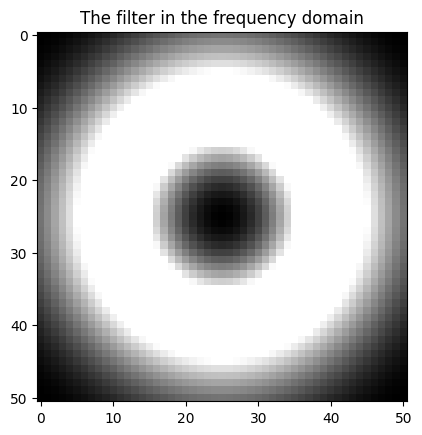

```
array([[0.        , 0.00207751, 0.00813266, ..., 0.00813266, 0.00207751,
        0.        ],
       [0.00207751, 0.00848225, 0.01894997, ..., 0.01894997, 0.00848225,
        0.00207751],
       [0.00813266, 0.01894997, 0.03392901, ..., 0.03392901, 0.01894997,
        0.00813266],
       ...,
       [0.00813266, 0.01894997, 0.03392901, ..., 0.03392901, 0.01894997,
        0.00813266],
       [0.00207751, 0.00848225, 0.01894997, ..., 0.01894997, 0.00848225,
        0.00207751],
       [0.        , 0.00207751, 0.00813266, ..., 0.00813266, 0.00207751,
        0.        ]])
```

```python
bandPassFilter((50,50), 10,20)
```

# Exercise 8